# Lecture 14 - Aggregating Data

In the previous class we covered

- Missing values
- The basics of data cleaning

This class we will talk about

- Computing aggregate statistics by group
- Introduction to merging

# I. Import Libraries and Data

Key libraries

```python
import numpy as np
import pandas as pd
import matplotlib.pyplot as plt
```

Read dataset on car racing circuits

- https://en.wikipedia.org/wiki/Formula_One
- [See Data Source](https://www.kaggle.com/datasets/rohanrao/formula-1-world-championship-1950-2020)

```python
results = pd.read_csv("data_raw/results.csv")
```

The dataset "codebook" is a table with ...

- Key column information
- Main things: Field, Type, Key, and Description

[figure not shown]

```python
# The codebook contains basic about the columns
# "Field" is the name given to the name of the column
# "Type"  is the variable type:
#         integer (int)
#         string (varchar - "variable character")
#         float (float)
#         The number in parenthesis is the maximum number of characters/digits
#         For most purposes we can ignore the numbers in parentheses.
# "Key" denotes whether this is the primary key "PRI" (also known as the identifier)
#         This is a column with unique values, that uniquely identifies each row
# "Description" contains a label with the content of the variable
```

Get column names + types

- Do types match the codebook?
- If not the data may need to be cleaned

```python
# This code displays column types
# "int" or "float" objects are numneric
# "object" typically denotes strings
# If a column that's supposed to be "numeric" but appears as "object"
# then it needs to be cleaned and converted to numeric

results.dtypes
```

```
resultId             int64
raceId               int64
driverId             int64
constructorId        int64
number              object
grid                 int64
position            object
positionText        object
positionOrder        int64
points             float64
laps                 int64
time                object
milliseconds        object
fastestLap          object
rank                object
fastestLapTime      object
fastestLapSpeed     object
statusId             int64
dtype: object
```

Try it yourself!

- How many rows does the dataset have?
- How many unique values are there for the columns  
  $\qquad$ "resultId"?  
  $\qquad$ "raceId"?  
  $\qquad$ "driverId"?

HINT: Use the "len()" and the "pd.unique()" functions

```python
# Write your own code here

print(len(results))

print(len(pd.unique(results["resultId"])))
print(len(pd.unique(results["raceId"])))
print(len(pd.unique(results["driverId"])))
```

```
25840
25840
1079
855
```

# II. Aggregate + groupby

Splitting code into multiple lines

- Makes it easier to read
- Simply wrap the code in round parentheses "()"

```python
# The following code computes descriptive statistics for points
# Wrapping the code in parentheses "()" allows you to split it into multiple
# lines. It's considered good practice to make each line less than 80 characters
# This makes it easier to scroll up and down without going sideways.

descriptives_singleline = (results["points"]
                           .describe())

descriptives_singleline
```

```
count    25840.000000
mean         1.877053
std          4.169849
min          0.000000
25%          0.000000
50%          0.000000
75%          2.000000
max         50.000000
Name: points, dtype: float64
```

Aggregate statistics

```python
# The ".agg()" subfunction computes aggregate statistics
# The syntax is ("column_name","function_name")
# The first argument is the column name
# The second argument is the function_name
# The command works with single quotations '...' or double "..."

results_agg = results.agg(mean_points = ('points','mean'),
                          sd_points =   ('points','std'),
                          min_points =  ('points','min'),
                          max_points =  ('points','max'),
                          count_obs   = ('points',len))

display(results_agg)
```

|  | points |
| --- | --- |
| mean_points | 1.877053 |
| sd_points | 4.169849 |
| min_points | 0.000000 |
| max_points | 50.000000 |
| count_obs | 25840.000000 |

Groupby + Aggregate statistics

[figure not shown]

```python
# In this cases drivers engage in multiple car races
# We can compute the aggregate statistics for each specific driver across
# multiple car races

drivers_agg = (results.groupby("driverId")
                      .agg(mean_points = ('points','mean'),
                           sd_points =   ('points','std'),
                           min_points =  ('points','min'),
                           max_points =  ('points','max'),
                           count_obs   = ('points',len)))

drivers_agg
```

| driverId | mean_points | sd_points | min_points | max_points | count_obs |
| --- | --- | --- | --- | --- | --- |
| 1 | 14.182258 | 9.224098 | 0.0 | 50.0 | 310 |
| 2 | 1.407609 | 2.372923 | 0.0 | 15.0 | 184 |
| 3 | 7.740291 | 8.672456 | 0.0 | 25.0 | 206 |
| 4 | 5.756983 | 6.330721 | 0.0 | 25.0 | 358 |
| 5 | 0.937500 | 1.969503 | 0.0 | 10.0 | 112 |
| ... | ... | ... | ... | ... | ... |
| 852 | 1.000000 | 2.477808 | 0.0 | 12.0 | 44 |
| 853 | 0.000000 | 0.000000 | 0.0 | 0.0 | 22 |
| 854 | 0.272727 | 1.335798 | 0.0 | 8.0 | 44 |
| 855 | 0.272727 | 0.882735 | 0.0 | 4.0 | 22 |
| 856 | 2.000000 | NaN | 2.0 | 2.0 | 1 |

855 rows × 5 columns

```python
results.loc[results['driverId']==1, ['points']].mean()
```

```
points    14.182258
dtype: float64
```

Groupby + Aggregate statistics (multigroup)

```python
# We can aggregate statistics from multiple columns by
# entering a list of column names in "groupby"
# In this case "constructor" in this case denotes the team
# The following computes aggregate point stats for each (team, race) combination

teamrace_agg = (results.groupby(  ["raceId","constructorId"]    )
                       .agg(mean_points = ('points','mean'),
                            sd_points =   ('points','std'),
                            min_points =  ('points','min'),
                            max_points =  ('points','max'),
                            count_obs   = ('points',len)))

teamrace_agg
```

| raceId | constructorId | mean_points | sd_points | min_points | max_points | count_obs |
| --- | --- | --- | --- | --- | --- | --- |
| 1 | 1 | 0.0 | 0.000000 | 0.0 | 0.0 | 2 |
|  | 2 | 0.0 | 0.000000 | 0.0 | 0.0 | 2 |
|  | 3 | 1.5 | 2.121320 | 0.0 | 3.0 | 2 |
|  | 4 | 2.0 | 2.828427 | 0.0 | 4.0 | 2 |
|  | 5 | 1.5 | 0.707107 | 1.0 | 2.0 | 2 |
| ... | ... | ... | ... | ... | ... | ... |
| 1096 | 117 | 2.5 | 2.121320 | 1.0 | 4.0 | 2 |
|  | 131 | 5.0 | 7.071068 | 0.0 | 10.0 | 2 |
|  | 210 | 0.0 | 0.000000 | 0.0 | 0.0 | 2 |
|  | 213 | 0.0 | 0.000000 | 0.0 | 0.0 | 2 |
|  | 214 | 3.0 | 4.242641 | 0.0 | 6.0 | 2 |

12568 rows × 5 columns

Filtering + Grouping + Aggregating:

```
.query().groupby().agg()
```

- This sequential syntax is known as "chaining"

```python
# The following gets a subset of the data using .query()
# In this case we subset the data before computing aggregate statistics
# Note: "filtering" is often the word used to obtain a subset

teamrace_agg = (results.query("raceId >= 500")
                       .groupby(["raceId","constructorId"])
                        .agg(mean_points = ('points','mean'),
                             sd_points =   ('points','std'),
                             min_points =  ('points','min'),
                             max_points =  ('points','max'),
                             count_obs   = ('points',len)))
teamrace_agg
```

[output not shown]

```python
(results.query("raceId >= 500").groupby(["raceId","constructorId"]).
 agg(mean_points = ('points','mean')))
```

| raceId | constructorId | mean_points |
| --- | --- | --- |
| 500 | 1 | 0.0 |
|  | 3 | 1.0 |
|  | 4 | 4.5 |
|  | 6 | 0.0 |
|  | 21 | 0.5 |
| ... | ... | ... |
| 1096 | 117 | 2.5 |
|  | 131 | 5.0 |
|  | 210 | 0.0 |
|  | 213 | 0.0 |
|  | 214 | 3.0 |

6055 rows × 1 columns

Try it yourself!

- Create a new dataset by chaining  
  groups by "raceId" then computes the  
  aggregate statistics: "points" average  
  and "laps" average

```python
# Write your own code

formula1_stats = (results.groupby("raceId")
                         .agg(mean_points = ('points','mean'),
                              laps_points = ('laps','mean'))  )

formula1_stats
```

| raceId | mean_points | laps_points |
| --- | --- | --- |
| 1 | 1.950 | 50.25 |
| 2 | 0.975 | 27.70 |
| 3 | 1.950 | 51.15 |
| 4 | 1.950 | 56.25 |
| 5 | 1.950 | 47.10 |
| ... | ... | ... |
| 1092 | 5.050 | 25.20 |
| 1093 | 5.100 | 49.50 |
| 1094 | 5.100 | 68.90 |
| 1095 | 5.100 | 62.80 |
| 1096 | 5.100 | 55.85 |

1079 rows × 2 columns

Try it yourself!

- Create a new dataset by chaining  
  groups by "constructorId" (the team) then  
  computes the average number of "points"
- Add a chain ".sort_values(...,ascending = False)"  
  to sort by team points in desceding order

```python
# Write your own code

constructor_agg = (results.groupby("constructorId")
                   .agg(mean_points = ("points", "mean"))
                   .sort_values(by = "mean_points", ascending = False))

constructor_agg
```

| constructorId | mean_points |
| --- | --- |
| 131 | 12.363643 |
| 9 | 9.117816 |
| 23 | 5.058824 |
| 208 | 4.584416 |
| 6 | 4.317968 |
| ... | ... |
| 76 | 0.000000 |
| 77 | 0.000000 |
| 78 | 0.000000 |
| 130 | 0.000000 |
| 112 | 0.000000 |

210 rows × 1 columns

# III. Relative statistics within group

Merging

[figure not shown]

```python
drivers_agg
```

| driverId | mean_points | sd_points | min_points | max_points | count_obs |
| --- | --- | --- | --- | --- | --- |
| 1 | 14.182258 | 9.224098 | 0.0 | 50.0 | 310 |
| 2 | 1.407609 | 2.372923 | 0.0 | 15.0 | 184 |
| 3 | 7.740291 | 8.672456 | 0.0 | 25.0 | 206 |
| 4 | 5.756983 | 6.330721 | 0.0 | 25.0 | 358 |
| 5 | 0.937500 | 1.969503 | 0.0 | 10.0 | 112 |
| ... | ... | ... | ... | ... | ... |
| 852 | 1.000000 | 2.477808 | 0.0 | 12.0 | 44 |
| 853 | 0.000000 | 0.000000 | 0.0 | 0.0 | 22 |
| 854 | 0.272727 | 1.335798 | 0.0 | 8.0 | 44 |
| 855 | 0.272727 | 0.882735 | 0.0 | 4.0 | 22 |
| 856 | 2.000000 | NaN | 2.0 | 2.0 | 1 |

855 rows × 5 columns

```python
results
```

|  | resultId | raceId | driverId | constructorId | number | grid | position | positionText | positionOrder | points | laps | time | milliseconds | fastestLap | rank | fastestLapTime | fastestLapSpeed | statusId |
| --- | --- | --- | --- | --- | --- | --- | --- | --- | --- | --- | --- | --- | --- | --- | --- | --- | --- | --- |
| 0 | 1 | 18 | 1 | 1 | 22 | 1 | 1 | 1 | 1 | 10.0 | 58 | 1:34:50.616 | 5690616 | 39 | 2 | 1:27.452 | 218.300 | 1 |
| 1 | 2 | 18 | 2 | 2 | 3 | 5 | 2 | 2 | 2 | 8.0 | 58 | +5.478 | 5696094 | 41 | 3 | 1:27.739 | 217.586 | 1 |
| 2 | 3 | 18 | 3 | 3 | 7 | 7 | 3 | 3 | 3 | 6.0 | 58 | +8.163 | 5698779 | 41 | 5 | 1:28.090 | 216.719 | 1 |
| 3 | 4 | 18 | 4 | 4 | 5 | 11 | 4 | 4 | 4 | 5.0 | 58 | +17.181 | 5707797 | 58 | 7 | 1:28.603 | 215.464 | 1 |
| 4 | 5 | 18 | 5 | 1 | 23 | 3 | 5 | 5 | 5 | 4.0 | 58 | +18.014 | 5708630 | 43 | 1 | 1:27.418 | 218.385 | 1 |
| ... | ... | ... | ... | ... | ... | ... | ... | ... | ... | ... | ... | ... | ... | ... | ... | ... | ... | ... |
| 25835 | 25841 | 1096 | 854 | 210 | 47 | 12 | 16 | 16 | 16 | 0.0 | 57 | \N | \N | 39 | 12 | 1:29.833 | 211.632 | 11 |
| 25836 | 25842 | 1096 | 825 | 210 | 20 | 16 | 17 | 17 | 17 | 0.0 | 57 | \N | \N | 40 | 20 | 1:31.158 | 208.556 | 11 |
| 25837 | 25843 | 1096 | 1 | 131 | 44 | 5 | 18 | 18 | 18 | 0.0 | 55 | \N | \N | 42 | 11 | 1:29.788 | 211.738 | 9 |
| 25838 | 25844 | 1096 | 849 | 3 | 6 | 20 | 19 | 19 | 19 | 0.0 | 55 | \N | \N | 45 | 14 | 1:30.309 | 210.517 | 130 |
| 25839 | 25845 | 1096 | 4 | 214 | 14 | 10 | \N | R | 20 | 0.0 | 27 | \N | \N | 24 | 17 | 1:30.579 | 209.889 | 47 |

25840 rows × 18 columns

```python
# This command merges the "aggregate" information in "driver_agg" into
# "results" as shown in the figure
# The merging variable "on" is determined by "driverId", which is a column
# that is common to both datasets
# "how = left" indicates that the left dataset is the baseline
#
# Note: For this method to work well "driverId" needs to contain unique alues
# in "drivers_agg". If not you may need to clean the data beforehand

results_merge = pd.merge(results,
                         drivers_agg,
                         on = "driverId",
                         how = "left")
```

```python
results_merge
```

|  | resultId | raceId | driverId | constructorId | number | grid | position | positionText | positionOrder | points | ... | fastestLap | rank | fastestLapTime | fastestLapSpeed | statusId | mean_points | sd_points | min_points | max_points | count_obs |
| --- | --- | --- | --- | --- | --- | --- | --- | --- | --- | --- | --- | --- | --- | --- | --- | --- | --- | --- | --- | --- | --- |
| 0 | 1 | 18 | 1 | 1 | 22 | 1 | 1 | 1 | 1 | 10.0 | ... | 39 | 2 | 1:27.452 | 218.300 | 1 | 14.182258 | 9.224098 | 0.0 | 50.0 | 310 |
| 1 | 2 | 18 | 2 | 2 | 3 | 5 | 2 | 2 | 2 | 8.0 | ... | 41 | 3 | 1:27.739 | 217.586 | 1 | 1.407609 | 2.372923 | 0.0 | 15.0 | 184 |
| 2 | 3 | 18 | 3 | 3 | 7 | 7 | 3 | 3 | 3 | 6.0 | ... | 41 | 5 | 1:28.090 | 216.719 | 1 | 7.740291 | 8.672456 | 0.0 | 25.0 | 206 |
| 3 | 4 | 18 | 4 | 4 | 5 | 11 | 4 | 4 | 4 | 5.0 | ... | 58 | 7 | 1:28.603 | 215.464 | 1 | 5.756983 | 6.330721 | 0.0 | 25.0 | 358 |
| 4 | 5 | 18 | 5 | 1 | 23 | 3 | 5 | 5 | 5 | 4.0 | ... | 43 | 1 | 1:27.418 | 218.385 | 1 | 0.937500 | 1.969503 | 0.0 | 10.0 | 112 |
| ... | ... | ... | ... | ... | ... | ... | ... | ... | ... | ... | ... | ... | ... | ... | ... | ... | ... | ... | ... | ... | ... |
| 25835 | 25841 | 1096 | 854 | 210 | 47 | 12 | 16 | 16 | 16 | 0.0 | ... | 39 | 12 | 1:29.833 | 211.632 | 11 | 0.272727 | 1.335798 | 0.0 | 8.0 | 44 |
| 25836 | 25842 | 1096 | 825 | 210 | 20 | 16 | 17 | 17 | 17 | 0.0 | ... | 40 | 20 | 1:31.158 | 208.556 | 11 | 1.260563 | 2.771894 | 0.0 | 18.0 | 142 |
| 25837 | 25843 | 1096 | 1 | 131 | 44 | 5 | 18 | 18 | 18 | 0.0 | ... | 42 | 11 | 1:29.788 | 211.738 | 9 | 14.182258 | 9.224098 | 0.0 | 50.0 | 310 |
| 25838 | 25844 | 1096 | 849 | 3 | 6 | 20 | 19 | 19 | 19 | 0.0 | ... | 45 | 14 | 1:30.309 | 210.517 | 130 | 0.147541 | 0.813143 | 0.0 | 6.0 | 61 |
| 25839 | 25845 | 1096 | 4 | 214 | 14 | 10 | \N | R | 20 | 0.0 | ... | 24 | 17 | 1:30.579 | 209.889 | 47 | 5.756983 | 6.330721 | 0.0 | 25.0 | 358 |

25840 rows × 23 columns

Check out another approach to compute  
aggregate statistics using `.transform()`  
in the optional lecture!

Try it yourself!

- Compute a scatter plot with ...
- "points" (y-axis) vs "mean_points" (x-axis)

Note: This plots tells you how much a driver's  
performance on individual races deviates from  
their overall average

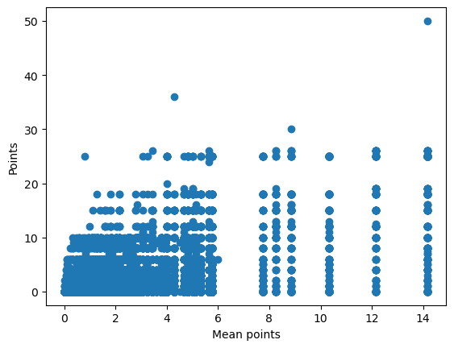

```python
# Write your own code

plt.scatter(x = results_merge["mean_points"],y=results_merge["points"])
plt.xlabel("Mean points")
plt.ylabel("Points")
```

Try it yourself!

- Merge the "teamrace_agg" data into "results"
- This time use the option:

$\qquad$ `on = ["raceId","constructorId"]`

```python
# Write your own code
```